# BIOSTAT 707 Homework 2

Huiyue Li

10/21/2021

```r
# load package
library(tidyverse)
library(knitr)
library(patchwork)
library(ggfortify)
library(factoextra)
library(caTools)
library(class)
library(gmodels)
library(caret)
```

### Data Preparation

#### 1. Import data and look at the first 5 lines

```r
hcv=read.csv("hcv.csv") #load data
### first 5 lines
head(hcv,5)
```

```
##   X      Category Age Sex  ALB  ALP  ALT  AST  BIL   CHE CHOL CREA  GGT PROT
## 1 1 0=Blood Donor  32   m 38.5 52.5  7.7 22.1  7.5  6.93 3.23  106 12.1 69.0
## 2 2 0=Blood Donor  32   m 38.5 70.3 18.0 24.7  3.9 11.17 4.80   74 15.6 76.5
## 3 3 0=Blood Donor  32   m 46.9 74.7 36.2 52.6  6.1  8.84 5.20   86 33.2 79.3
## 4 4 0=Blood Donor  32   m 43.2 52.0 30.6 22.6 18.9  7.33 4.74   80 33.8 75.7
## 5 5 0=Blood Donor  32   m 39.2 74.1 32.6 24.8  9.6  9.15 4.32   76 29.9 68.7
```

```r
summary(hcv)
```

```
##        X                           Category        Age        Sex
##  Min.   :  1.0   0=Blood Donor         :533   Min.   :19.00   f:238
##  1st Qu.:154.5   0s=suspect Blood Donor:  7   1st Qu.:39.00   m:377
##  Median :308.0   1=Hepatitis           : 24   Median :47.00
##  Mean   :308.0   2=Fibrosis            : 21   Mean   :47.41
##  3rd Qu.:461.5   3=Cirrhosis           : 30   3rd Qu.:54.00
##  Max.   :615.0                                Max.   :77.00
##
##       ALB             ALP              ALT              AST
##  Min.   :14.90   Min.   : 11.30   Min.   :  0.90   Min.   : 10.60
##  1st Qu.:38.80   1st Qu.: 52.50   1st Qu.: 16.40   1st Qu.: 21.60
##  Median :41.95   Median : 66.20   Median : 23.00   Median : 25.90
##  Mean   :41.62   Mean   : 68.28   Mean   : 28.45   Mean   : 34.79
##  3rd Qu.:45.20   3rd Qu.: 80.10   3rd Qu.: 33.08   3rd Qu.: 32.90
##  Max.   :82.20   Max.   :416.60   Max.   :325.30   Max.   :324.00
##  NA's   :1       NA's   :18       NA's   :1
##       BIL             CHE              CHOL            CREA
##  Min.   :  0.8   Min.   : 1.420   Min.   :1.430   Min.   :   8.00
##  1st Qu.:  5.3   1st Qu.: 6.935   1st Qu.:4.610   1st Qu.:  67.00
##  Median :  7.3   Median : 8.260   Median :5.300   Median :  77.00
##  Mean   : 11.4   Mean   : 8.197   Mean   :5.368   Mean   :  81.29
##  3rd Qu.: 11.2   3rd Qu.: 9.590   3rd Qu.:6.060   3rd Qu.:  88.00
##  Max.   :254.0   Max.   :16.410   Max.   :9.670   Max.   :1079.10
##                                   NA's   :10
##       GGT              PROT
##  Min.   :  4.50   Min.   :44.80
##  1st Qu.: 15.70   1st Qu.:69.30
##  Median : 23.30   Median :72.20
##  Mean   : 39.53   Mean   :72.04
##  3rd Qu.: 40.20   3rd Qu.:75.40
##  Max.   :650.90   Max.   :90.00
##                   NA's   :1
```

```r
# a. observation
ob=nrow(hcv)
ob
```

```
## [1] 615
```

```r
# b. variable
va=ncol(hcv)
va-2 # exclude X and Category
```

```
## [1] 12
```

```r
# c. missing data
sum_na_name=names(which(colSums(is.na(hcv))>0))
sum_na=colSums(is.na(hcv))[colSums(is.na(hcv))>0]
sum_na_name
```

```
## [1] "ALB"  "ALP"  "ALT"  "CHOL" "PROT"
```

```r
sum_na
```

```
##  ALB  ALP  ALT CHOL PROT
##    1   18    1   10    1
```

```r
# d. positive and negative
hcv1=hcv%>%mutate(diagnosis=if_else(grepl("0",as.character(Category)), "Negative", "Positive")) #add column
#positive
sum_po=sum(hcv1$diagnosis=="Positive")
sum_po
```

```
## [1] 75
```

```r
#negative
sum_ne=sum(hcv1$diagnosis=="Negative")
sum_ne
```

```
## [1] 540
```

**a.** There are 615 observation.

**b.** There are 12 independent variables.

**c.** The columns ALB, ALP, ALT, CHOL, PROT have missing value, and respectively 1, 18, 1, 10, 1 values were missing in these columns (ALB, ALP, ALT, CHOL, PROT).

**d.** There are 75 observations with positive diagnosis and 540 observations with negative diagnosis.

#### 3. Perform the following tasks

```r
# drop NA
hcv2=hcv1%>%na.omit()
# convert sex variable
table(hcv2$Sex) #check Sex only with f and m values
```

```
##
##   f   m
## 226 363
```

```r
hcv3=hcv2%>%mutate(Sex=if_else(Sex=="m",1,0))
hcv3$Sex=as.integer(hcv3$Sex) #interger form
# convert Category variable
hcv4=hcv3%>%mutate(Category=if_else(grepl("0",as.character(Category)), FALSE,TRUE))
```

#### 4.Table and downsampling

1. To determine how many positive observations and negative observations are in the dataset with modifying the dimnames (FALSE refer to negative diagnosis, TRUE refer to positive diagnosis)

```r
tab=table(hcv4$Category)
tab
```

```
##
## FALSE  TRUE
##   533    56
```

```r
dimnames(tab)=list(c("FALSE(Negative)","TRUE(Positive)")) #change the names for comments
tab
```

```
## FALSE(Negative)  TRUE(Positive)
##             533              56
```

Based on the results, we can find that there are 56 positive observations and 533 negative observations. The negative observations are much more than positive observations.

2. Perform downsampling

```r
# separate the dataframe
hcv_po=hcv4%>%filter(Category==T)%>%select(-diagnosis)
hcv_ne=hcv4%>%filter(Category==F)%>%select(-diagnosis)
# count in the positive diagnosis dataframe (sex and age)
hcv_po1=hcv_po%>%group_by(Sex,Age)%>%summarise(count=n())
hcv_ne1=NULL
hcv_po1=as.data.frame(hcv_po1)
# sample
set.seed(2021)
for (i in 1:nrow(hcv_po1)) {
  ne1=hcv_ne%>%filter(Sex==hcv_po1[i,1] & Age==hcv_po1[i,2])
if(nrow(ne1)>=hcv_po1[i,3]){
  ne1_1=ne1[sample(nrow(ne1),hcv_po1[i,3]),]
}
 else {
   ne1_1=ne1
 }
  hcv_ne1=rbind(hcv_ne1,ne1_1)
}
# merge together
hcv5=rbind(hcv_po,hcv_ne1)
```

### 5. Plot the histograms

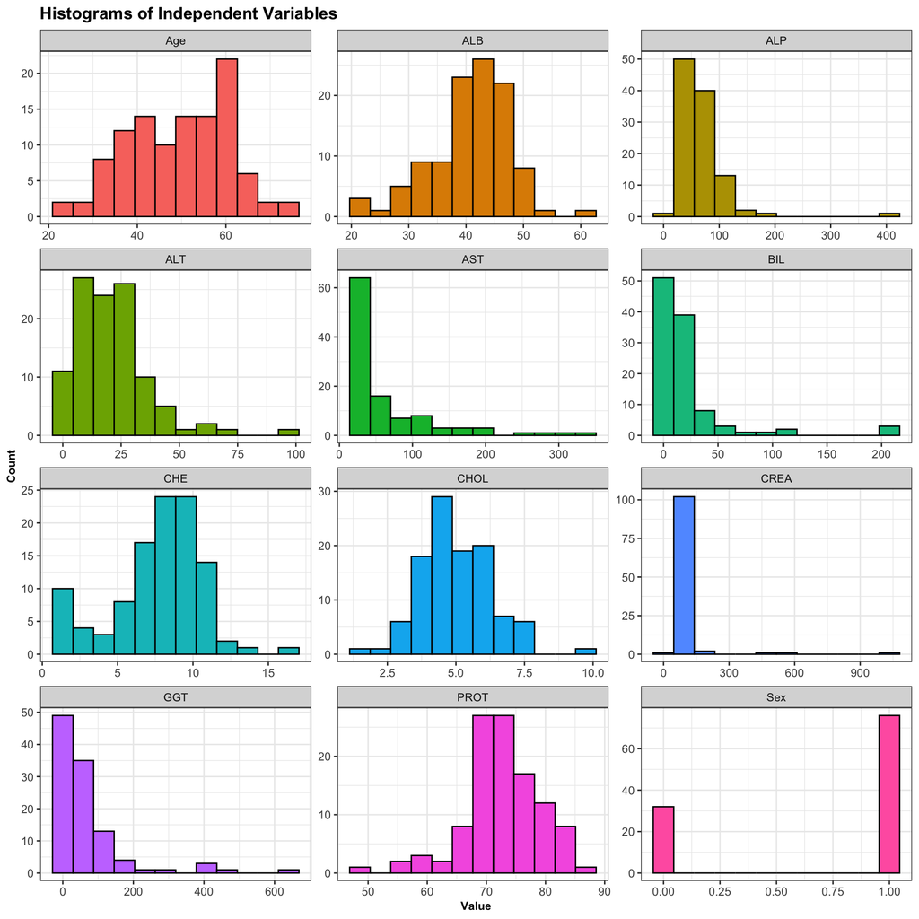

```r
hcv6=hcv5%>%select(-X,-Category)%>%gather("key","value") #trans
ggplot(hcv6,aes(x =value, fill=key)) +geom_histogram(bins = 12, colour="black") +ggtitle("Histograms of Independent Variables")+xlab( "Value")+ylab("Count") +theme_bw()+theme(axis.text=element_text(size=9),axis.title=element_text(size=9,face="bold"),title = element_text(size = 11,face = "bold"))+facet_wrap(~factor(key),nrow = 4,ncol = 3,scales = "free")+theme(legend.position="none")
```

### 6.Scale

```r
hcv_scale=hcv5 #variable
hcv_scale[,-c(1,2,4)]=scale(hcv_scale[,-c(1,2,4)])
hcv_pre=as_tibble(hcv_scale,rownames = NA)
```

Because we choose the number of principal components for PCA based on the maximum variance explained, if without scaling (which enables variables to have standard deviation equal to 1), different units will bias the results of PCA.

### Principal Component Analysis (PCA)

#### 7.Calculate principal components

```r
# pca result
pca=princomp(hcv_pre[,3:ncol(hcv_pre)])
summary(pca,loadings = T)
```

```
## Importance of components:
##                           Comp.1    Comp.2    Comp.3     Comp.4     Comp.5
## Standard deviation     1.8438987 1.2312635 1.1852343 1.05163617 0.92233161
## Proportion of Variance 0.3061194 0.1364957 0.1264810 0.09957443 0.07659334
## Cumulative Proportion  0.3061194 0.4426151 0.5690961 0.66867050 0.74526384
##                            Comp.6     Comp.7     Comp.8     Comp.9    Comp.10
## Standard deviation     0.88301016 0.73820977 0.68832780 0.65043093 0.50805253
## Proportion of Variance 0.07020179 0.04906552 0.04265868 0.03809072 0.02323989
## Cumulative Proportion  0.81546563 0.86453114 0.90718982 0.94528054 0.96852043
##                           Comp.11    Comp.12
## Standard deviation     0.44529295 0.38903320
## Proportion of Variance 0.01785289 0.01362668
## Cumulative Proportion  0.98637332 1.00000000
##
## Loadings:
##      Comp.1 Comp.2 Comp.3 Comp.4 Comp.5 Comp.6 Comp.7 Comp.8 Comp.9 Comp.10
## Age   0.199  0.275  0.152  0.583  0.114  0.504  0.367         0.344
## Sex                       -0.113                       0.123  0.304
## ALB  -0.460        -0.141        -0.222                       0.485 -0.159
## ALP   0.213  0.634                      -0.160        -0.485 -0.105 -0.483
## ALT  -0.273        -0.385 -0.178  0.596         0.489 -0.290         0.209
## AST   0.257 -0.167 -0.595                0.234  0.129  0.450 -0.111 -0.500
## BIL   0.337 -0.175         0.146 -0.200 -0.678  0.311         0.428 -0.108
## CHE  -0.456  0.179                0.106        -0.245  0.267  0.339 -0.315
## CHOL -0.289  0.424         0.283        -0.389  0.240  0.509 -0.372
## CREA         0.249  0.303 -0.679 -0.258  0.178  0.481  0.192
## GGT   0.256  0.427 -0.462                      -0.315  0.176  0.228  0.565
## PROT -0.288        -0.367  0.167 -0.666  0.120  0.234 -0.239 -0.194
##      Comp.11 Comp.12
## Age
## Sex  -0.143   0.916
## ALB  -0.632  -0.222
## ALP           0.140
## ALT   0.111
## AST
## BIL   0.183
## CHE   0.629
## CHOL -0.191
## CREA
## GGT          -0.141
## PROT  0.296   0.227
```

#### 8. Scree plot

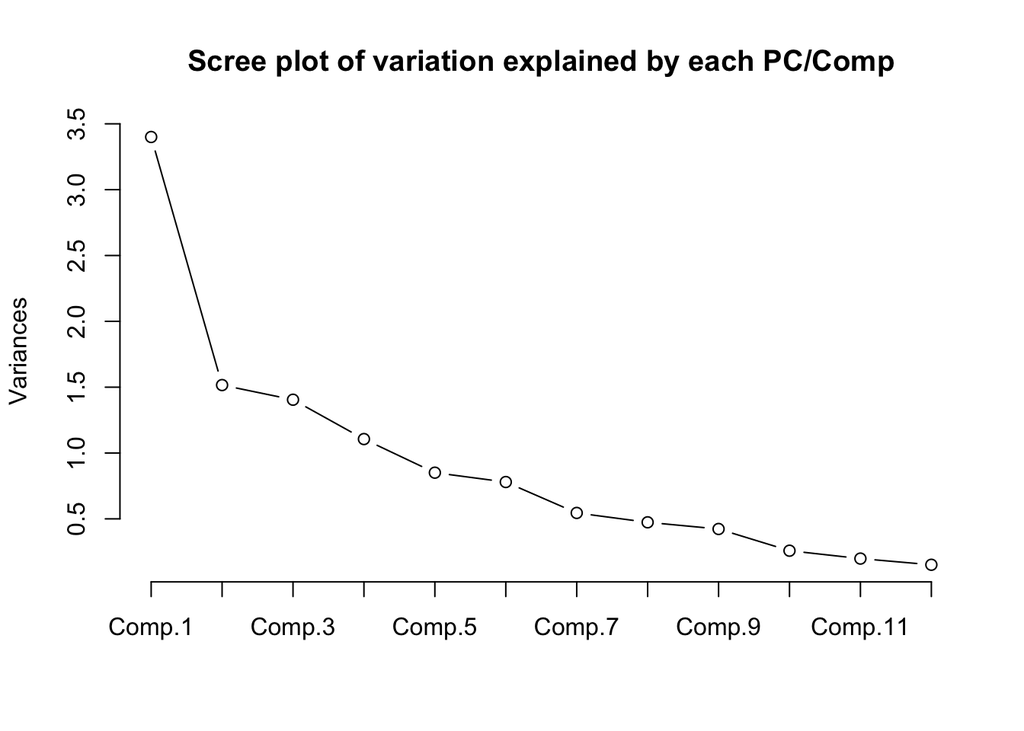

```r
screeplot(pca,type = "lines",npcs = 12,main = "Scree plot of variation explained by each PC/Comp")
```

#### 9.Plot using patchwork/gridExtra

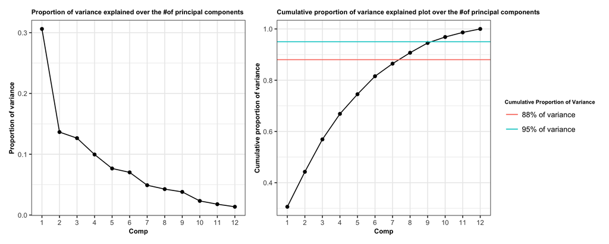

```r
# proportion of variance
sdv=summary(pca)[[1]]
por=data.frame(sdv^2/sum(sdv^2))
por_com=cbind(por,1:12)
rownames(por_com)=1:12
colnames(por_com)=c("Por","Comp")
#cumulative proportion of variance
cum=cumsum(por)
cum_com=cbind(cum,1:12)
rownames(cum_com)=1:12
colnames(cum_com)=c("Cum","Comp")
# a. plot
p1=ggplot(data = por_com,mapping =aes(x=as.factor(Comp),y=Por,group=1))+geom_line()+geom_point()+ggtitle ("Proportion of variance explained over the #of principal components")+ylab("Proportion of variance")+xlab("Comp")+ theme_bw()+theme(axis.text=element_text(size=8),axis.title=element_text(size=8,face="bold"),title = element_text(size = 6.5,face = "bold"))
#b plot
p2=ggplot(data = cum_com,mapping =aes(x=as.factor(Comp),y=Cum,group=1))+geom_line()+geom_point()+ggtitle ("Cumulative proportion of variance explained plot over the #of principal components")+ylab("Cumulative proportion of variance")+xlab("Comp")+geom_hline(aes(yintercept = 0.88,linetype="88% of variance"),colour="salmon")+geom_hline(aes(yintercept = 0.95,linetype="95% of variance"),colour="cyan3")+scale_linetype_manual(name = "Cumulative Proportion of Variance", values = c(1, 1),guide = guide_legend(override.aes = list(color = c("salmon", "cyan3"))))+theme_bw()+theme(axis.text=element_text(size=8),axis.title=element_text(size=8,face="bold"),title = element_text(size = 6.5,face = "bold"))
p1+p2+plot_layout(nrow = 1)
```

#### 10. Answer the question

```r
# first, second and the third principal components
por123=por_com[1:3,]
por123
```

```
##         Por Comp
## 1 0.3061194    1
## 2 0.1364957    2
## 3 0.1264810    3
```

```r
# 88% and 95% of variance
p88=min(cum_com[which(cum_com[,1]>0.88),2]) #88%
p95=min(cum_com[which(cum_com[,1]>0.95),2]) #95%
p88
```

```
## [1] 8
```

```r
p95
```

```
## [1] 10
```

Based on the result, the proportion of variance captured from first, second and the third principal components are respectively 30.6119432$\%$,13.6495655$\%$ and 12.6480983$\%$.  
To describe at least 88% and 95% of variance respective, we need correspondingly 8 and 10 principal components.

#### 11. Answer the question

```r
pca$loadings[,1]
```

```
##          Age          Sex          ALB          ALP          ALT          AST
##  0.199241554 -0.002065447 -0.459855309  0.213110043 -0.273385901  0.257224120
##          BIL          CHE         CHOL         CREA          GGT         PROT
##  0.336804093 -0.456033090 -0.289355254  0.093838004  0.256232944 -0.287960260
```

Based on the results, the top 3 variables that contribute the most to the variance captured from PC1 are `ALB`, `CHE` and `BIL`.

#### 12. Biplot

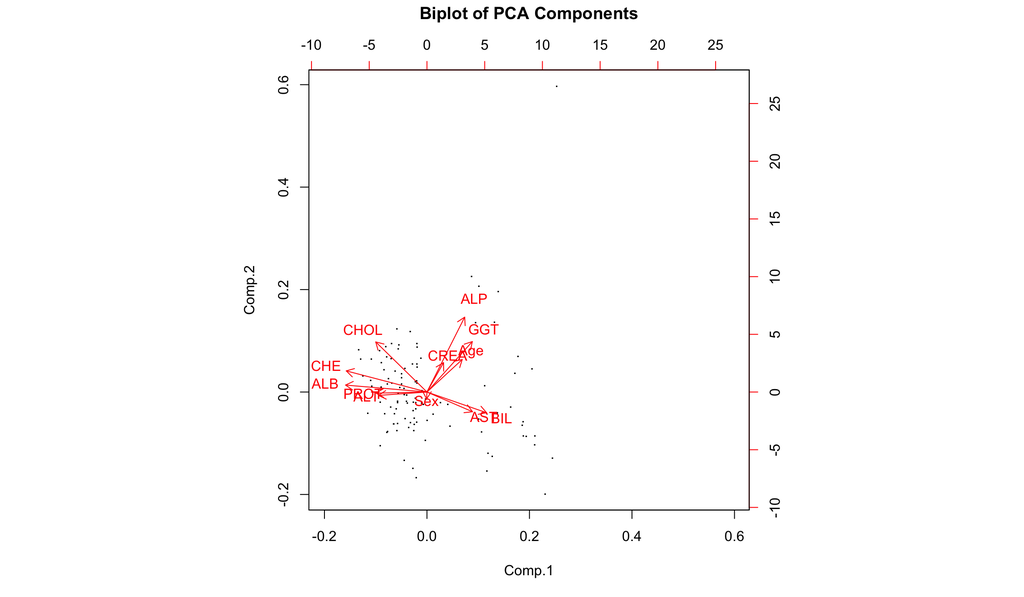

```r
biplot(pca,xlabs=rep(".",nrow(hcv_pre)))
title("Biplot of PCA Components",line=3)
```

#### 13. Clearer biplot

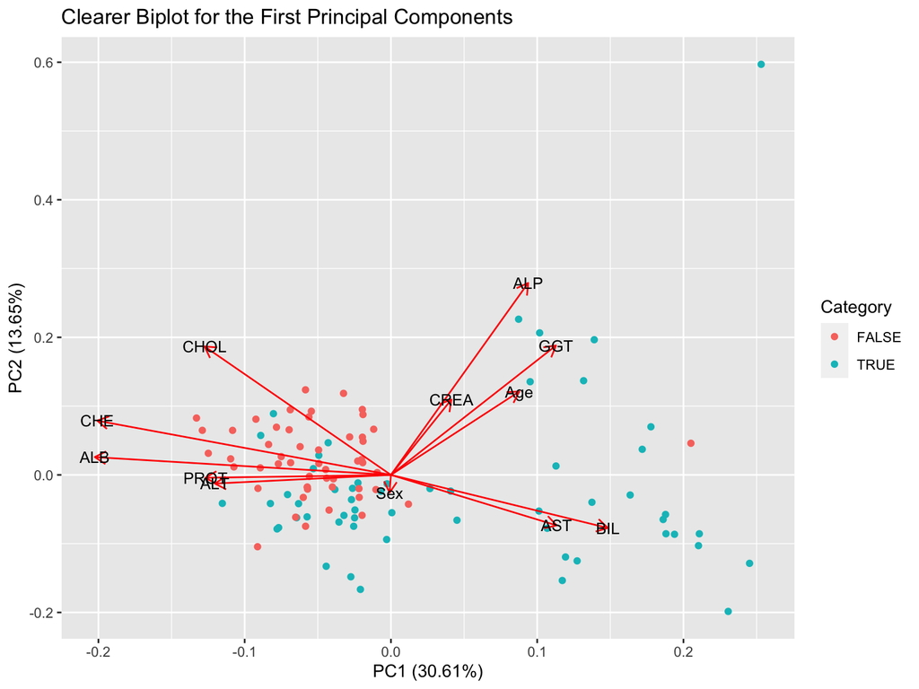

```r
autoplot(pca,data=hcv_pre,which="biplot",colour="Category",loadings=T,loadings.label=T,loadings.label.size=3.5,loadings.label.colour="black")+xlab("PC1 (30.61%)")+ylab("PC2 (13.65%)")+ggtitle("Clearer Biplot for the First Principal Components")
```

### Hierarchical Clustering

#### 14. Calculate a dissimilarity matrix using Euclidean distance and compute hierarchical clustering using the complete linkage method and plot the dendrogram.

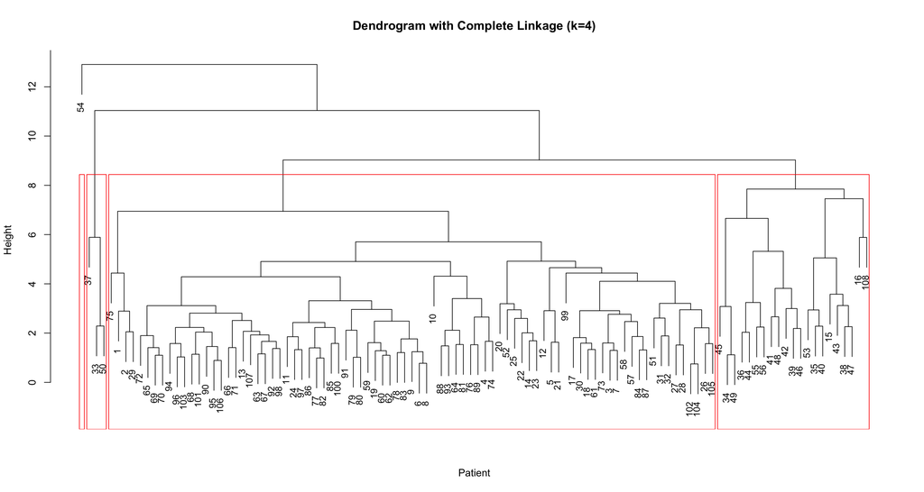

```r
# matrix
euc=as.matrix(dist(hcv_pre[,3:ncol(hcv_pre)],method = "euclidean"))
# compute hierarchical clustering
hc_comp=hclust(dist(hcv_pre[,3:ncol(hcv_pre)],method = "euclidean"),method='complete')
# plot
p3=plot(hc_comp,main='Dendrogram with Complete Linkage (k=4)',xlab="Patient",cex=.9,sub = "")
rect.hclust(hc_comp,k=4)
```

#### 15. Divide the dendrogram into 4 clusters using cutree() function and compare the compositions.

```r
# cutree
cut=cutree(hc_comp,4)
# table
table(cut)
```

```
## cut
##  1  2  3  4
## 83 21  3  1
```

```r
# compare
table(cut,hcv_pre$Category)
```

```
##
## cut FALSE TRUE
##   1    51   32
##   2     1   20
##   3     0    3
##   4     0    1
```

Based on the result, cluster 1 is FALSE, cluster 2，3 and 4 are TRUE.

#### 16. Classification accuracy

```r
# classify
pred_obs=data.frame(predict=ifelse(cut==1,FALSE,TRUE),observed=hcv_pre$Category)
compare=pred_obs%>%group_by(predict,observed)%>%summarise(count=n()) #compare
compare
```

```
## # A tibble: 4 x 3
## # Groups:   predict [2]
##   predict observed count
##   <lgl>   <lgl>    <int>
## 1 FALSE   FALSE       51
## 2 FALSE   TRUE        32
## 3 TRUE    FALSE        1
## 4 TRUE    TRUE        24
```

```r
accuracy=round(sum(compare[c(1,4),3])/sum(compare[,3]),4)*100 #accuracy
accuracy
```

```
## [1] 69.44
```

Based on the results, we can know the classification accuracy would be 69.44 $\%$, which is not too much high.

#### 17. Repeat 15 and 16 for 10 clusters

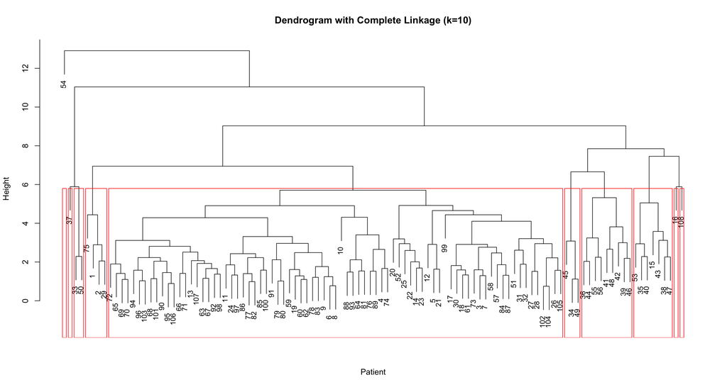

```r
p3=plot(hc_comp,main='Dendrogram with Complete Linkage (k=10)',xlab="Patient",cex=.9,sub = "")
rect.hclust(hc_comp,k=10) #plot for k=10
```

```r
cut_10=cutree(hc_comp,10) #cut for k=10
table(cut_10,hcv_pre$Category)# cluster 2 and 10 are FALSE, others are TRUE
```

```
##
## cut_10 FALSE TRUE
##     1      1    3
##     2     50   29
##     3      0    7
##     4      0    1
##     5      0    2
##     6      0    3
##     7      0    9
##     8      0    1
##     9      0    1
##     10     1    0
```

```r
pred_obs10=data.frame(predict=ifelse(cut_10 %in% c(2,10),FALSE,TRUE),observed=hcv_pre$Category)
compare10=pred_obs10%>%group_by(predict,observed)%>%summarise(count=n())
compare10
```

```
## # A tibble: 4 x 3
## # Groups:   predict [2]
##   predict observed count
##   <lgl>   <lgl>    <int>
## 1 FALSE   FALSE       51
## 2 FALSE   TRUE        29
## 3 TRUE    FALSE        1
## 4 TRUE    TRUE        27
```

```r
accuracy10=round(sum(compare10[c(1,4),3])/sum(compare10[,3]),4)*100
accuracy10
```

```
## [1] 72.22
```

For 10 cluster, here cluster 2 and cluster 10 are FALSE, other clusters are TRUE. Then the classification accuracy would be 72.22 $\%$, which is slightly higher than the result in `Question 16`.

#### 18. 4 clusters with Ward’s linkage method

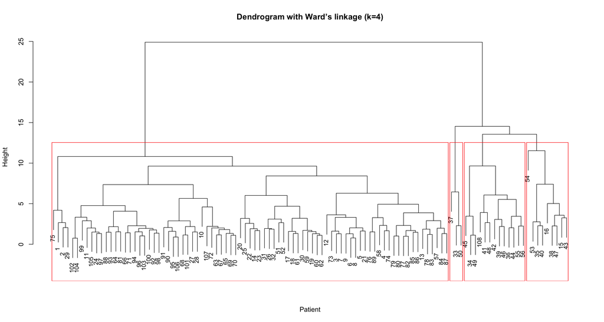

```r
hc_comp_w=hclust(dist(hcv_pre[,3:ncol(hcv_pre)],method = "euclidean"),method='ward.D2')
# plot
p4=plot(hc_comp_w,main='Dendrogram with Ward’s linkage (k=4)',xlab="Patient",cex=.9,sub = "")
rect.hclust(hc_comp_w,k=4)
```

```r
# table
cut_w_4=cutree(hc_comp_w,4)
# compare
table(cut_w_4)
```

```
## cut_w_4
##  1  2  3  4
## 83  9  3 13
```

```r
table(cut_w_4,hcv_pre$Category) # cluster 1 is FALSE, other clusters are TRUE
```

```
##
## cut_w_4 FALSE TRUE
##       1    51   32
##       2     0    9
##       3     0    3
##       4     1   12
```

```r
#accuracy
pred_obs_w4=data.frame(predict=ifelse(cut_w_4==1,FALSE,TRUE),observed=hcv_pre$Category)
compare_w4=pred_obs_w4%>%group_by(predict,observed)%>%summarise(count=n())
compare_w4
```

```
## # A tibble: 4 x 3
## # Groups:   predict [2]
##   predict observed count
##   <lgl>   <lgl>    <int>
## 1 FALSE   FALSE       51
## 2 FALSE   TRUE        32
## 3 TRUE    FALSE        1
## 4 TRUE    TRUE        24
```

```r
accuracy_w4=round(sum(compare_w4[c(1,4),3])/sum(compare_w4[,3]),4)*100
accuracy_w4
```

```
## [1] 69.44
```

For 4 cluster with Ward’s linkage method, here cluster 1 is FALSE, other clusters are TRUE. Then the classification accuracy would be 69.44 $\%$, which is the same as the result in `Question 16`.

#### 19. 10 clusters with Ward’s linkage method

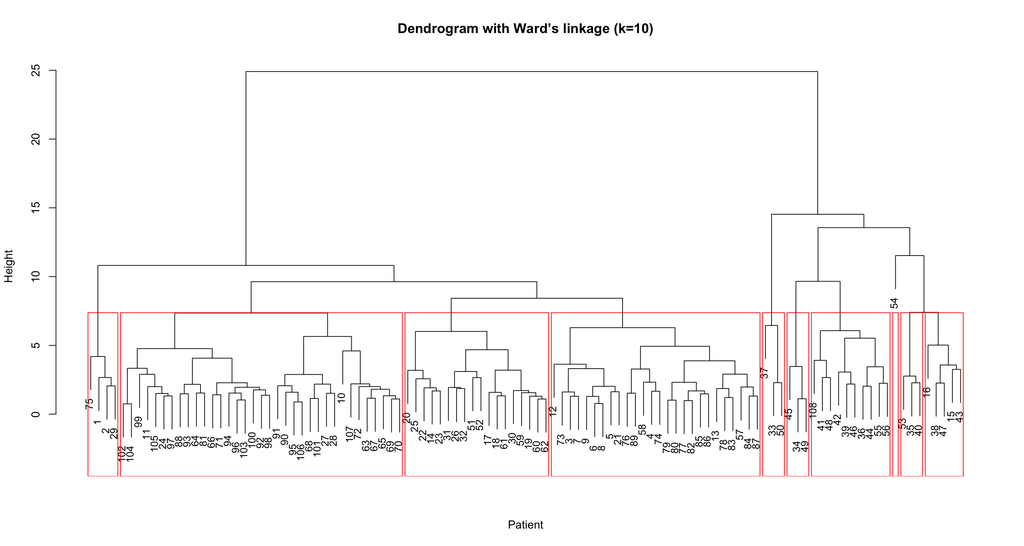

```r
hc_comp_w=hclust(dist(hcv_pre[,3:ncol(hcv_pre)],method = "euclidean"),method='ward.D2')
# plot
p4=plot(hc_comp_w,main='Dendrogram with Ward’s linkage (k=10)',xlab="Patient",cex=.9,sub = "")
rect.hclust(hc_comp_w,k=10)
```

```r
# table
cut_w_10=cutree(hc_comp_w,10)
# compare
table(cut_w_10)
```

```
## cut_w_10
##  1  2  3  4  5  6  7  8  9 10
##  4 26 35 18  5  3  3  3 10  1
```

```r
table(cut_w_10,hcv_pre$Category) # cluster 2 and 3 are FALSE, other clusters are TRUE
```

```
##
## cut_w_10 FALSE TRUE
##       1      1    3
##       2     16   10
##       3     30    5
##       4      4   14
##       5      0    5
##       6      0    3
##       7      0    3
##       8      0    3
##       9      1    9
##       10     0    1
```

```r
#accuracy
pred_obs_w10=data.frame(predict=ifelse(cut_w_10 %in% c(2,3),FALSE,TRUE),observed=hcv_pre$Category)
compare_w10=pred_obs_w10%>%group_by(predict,observed)%>%summarise(count=n())
compare_w10
```

```
## # A tibble: 4 x 3
## # Groups:   predict [2]
##   predict observed count
##   <lgl>   <lgl>    <int>
## 1 FALSE   FALSE       46
## 2 FALSE   TRUE        15
## 3 TRUE    FALSE        6
## 4 TRUE    TRUE        41
```

```r
accuracy_w10=round(sum(compare_w10[c(1,4),3])/sum(compare_w10[,3]),4)*100
accuracy_w10
```

```
## [1] 80.56
```

For 10 cluster with Ward’s linkage method, here cluster 2 and cluster 3 are FALSE, other clusters are TRUE. Then the classification accuracy would be 80.56 $\%$, which is higher than the result in `Question 16` and `Question 17 &18`.

#### 20. Comments for the previous 4 attempts at hierarchical clustering

Based on the the previous 4 attempts at hierarchical clustering, we can find that  
**(a)** The clustering result changes using different number of clusters when linkage are the same;  
**(b)** Higher number of clusters will lead to clustering result that is closer to the actual outcomes, not only for clustering using complete linkage method but also for clustering using Ward’s linkage method;  
**(c)** when the number of clusters is low and equal, and for clustering with complete linkage method or Ward’s linkage method, the classification accuracy results will be the same even though the correspondingly divided or non-divided dendrograms of clustering are both different; and when the number of clusters is high and the same, and for clustering with Ward’s linkage method, the classification accuracy results will be higher than using complete linkage method, also, the correspondingly divided or non-divided dendrograms of clustering are different.

### K-Means Clustering

#### 21.Compute k-means clustering on this dataset using the kmeans() function for two clusters.

```r
km.out=kmeans(hcv_pre[,3:ncol(hcv_pre)],centers=2) #kmeans
table=table(km.out$cluster,hcv_pre$Category) # cluster will change
table1=as.data.frame(table)
T_F=table1%>%filter(Var1==1)%>%arrange(desc(Freq))
pred_obs_km=data.frame(predict=if_else(km.out$cluster==1,T_F[1,2],T_F[2,2]),observed=hcv_pre$Category)
compare_km=pred_obs_km%>%group_by(predict,observed)%>%summarise(count=n())
compare_km
```

```
## # A tibble: 4 x 3
## # Groups:   predict [2]
##   predict observed count
##   <fct>   <lgl>    <int>
## 1 FALSE   FALSE       51
## 2 FALSE   TRUE        32
## 3 TRUE    FALSE        1
## 4 TRUE    TRUE        24
```

```r
accuracy_km=round(sum(compare_km[c(1,4),3])/sum(compare_km[,3]),4)*100
accuracy_km
```

```
## [1] 69.44
```

For 2 clusters with k-means clustering, here cluster 1 is FALSE, cluster 2 is TRUE. Then the clustering classification accuracy would be 69.44 $\%$.

#### 22. Visualize the clusters

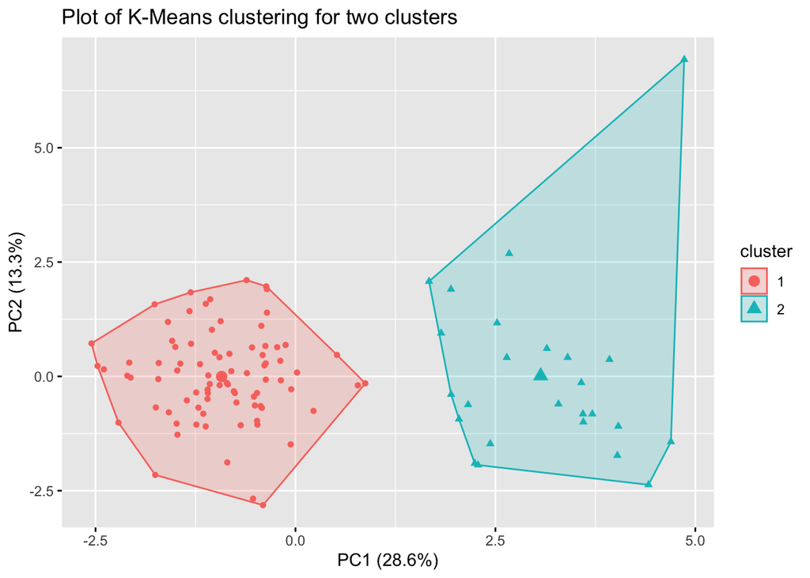

```r
fviz_cluster(km.out,data = hcv_pre[,3:ncol(hcv_pre)],geom = "point")+xlab("PC1 (28.6%)")+ylab("PC2 (13.3%)")+ggtitle("Plot of K-Means clustering for two clusters")
```

#### 23.Comments

Because the algorithm for k-means clustering requires us to pre-specify the number of clusters, whereas the hierarchical clustering does not, which is to treat every observation as its own cluster. Then, at each step, we merge the two clusters that are more similar until all observations are clustered together. Based on the pairwise dissimilarities and specific linkage, the dendrogram for the hierarchical clustering can be divided into k clusters later.  
In this dataset, the K-Means clustering seems to be more appropriate. Given `Question 20`, and because the accuracies of the hierarchical clustering for 4 clusters is the same as which of K-Means clustering for 2 clusters. Additionally, the distribution for these data points seems to be roundish. And here for the hierarchical clustering, we need to choose not only the appropriate K, as well as the appropriate linkage.

### kNN

#### 24. Sampling for kNN

```r
hcv_knn=hcv_pre

#sample
set.seed(2021)
split=sample.split(hcv_knn$Category,SplitRatio = 0.8)
train_df=subset(hcv_knn,split==TRUE)
test_df=subset(hcv_knn,split==FALSE)
# independent or not
X_train=train_df[,-c(1,2)]
y_train=train_df$Category
X_test=test_df[,-c(1,2)]
y_test=test_df$Category
```

#### 25. Generate a KNN model using the knn() function

```r
knn_model=knn(train=X_train,test=X_test,cl=y_train,k=sqrt(nrow(X_train)))
knn_model
```

```
##  [1] FALSE FALSE TRUE  TRUE  FALSE TRUE  FALSE FALSE FALSE TRUE  TRUE  FALSE
## [13] FALSE FALSE FALSE FALSE FALSE FALSE FALSE FALSE FALSE
## Levels: FALSE TRUE
```

#### 26. Produce a confusion matrix

```r
crotab=CrossTable(x=y_test,y=knn_model,prop.chisq = FALSE,prop.c = FALSE,prop.r = FALSE,prop.t = FALSE)
```

```
##
##
##    Cell Contents
## |-------------------------|
## |                       N |
## |-------------------------|
##
##
## Total Observations in Table:  21
##
##
##              | knn_model
##       y_test |     FALSE |      TRUE | Row Total |
## -------------|-----------|-----------|-----------|
##        FALSE |        10 |         0 |        10 |
## -------------|-----------|-----------|-----------|
##         TRUE |         6 |         5 |        11 |
## -------------|-----------|-----------|-----------|
## Column Total |        16 |         5 |        21 |
## -------------|-----------|-----------|-----------|
##
##
```

#### 27. False positives, accuracy, sensitivity, error rate, and precision

```r
TN=crotab[[1]][1,1] # true negatives
TP=crotab[[1]][2,2] #True positives
FN=crotab[[1]][2,1] #false negatives
FP=crotab[[1]][1,2] #false positives

#accuracy
accur=(TP+TN)/(TP+TN+FP+FN)
#sensitivity
sens=TP/(TP+FN)
# error rate
error=(FP+FN)/(TP+TN+FP+FN)
# precision
pres=TP/(TP+FP)

cat("False positives: ",FP,'\n',"Accuracy: ",accur,'\n',"Sensitivity: ",sens,'\n',"Error rate: ",error,'\n',"Precision: ",pres)
```

```
## False positives:  0
##  Accuracy:  0.7142857
##  Sensitivity:  0.4545455
##  Error rate:  0.2857143
##  Precision:  1
```

Therefore, we can get that the number of False positives is 0, Accuracy is 0.7142857, the Sensitivity is 0.4545455, the Error rate is 0.2857143 and the Precision is 1.

### K-fold cross validation with kNN, where K and k have different meanings

#### 28.

```r
set.seed(2021)
idx=createFolds(hcv_pre$Category,k=5) # get idx
sapply(idx,length)
```

```
## Fold1 Fold2 Fold3 Fold4 Fold5
##    22    22    22    21    21
```

```r
result=lapply(idx, function(x) {
  test_data_i=hcv_pre[x,]
  train_data_i=hcv_pre[-x,]
  X_train_i=train_data_i[,-c(1,2)]
  y_train_i=train_data_i$Category
  X_test_i=test_data_i[,-c(1,2)]
  y_test_i=test_data_i$Category
  knn_model_i=knn(train=X_train_i,test=X_test_i,cl=y_train_i,k=11)
  crotab_i=CrossTable(x=y_test_i,y=knn_model_i,prop.chisq = FALSE,prop.c = FALSE,prop.r = FALSE,prop.t = FALSE)
  TNi=crotab_i[[1]][1,1] # true negatives
  TPi=crotab_i[[1]][2,2] #True positives
  FNi=crotab_i[[1]][2,1] #false negatives
  FPi=crotab_i[[1]][1,2] # false positives
  erro=(FPi+FNi)/(TPi+TNi+FPi+FNi)
  return(erro)
})
```

```
##
##
##    Cell Contents
## |-------------------------|
## |                       N |
## |-------------------------|
##
##
## Total Observations in Table:  22
##
##
##              | knn_model_i
##     y_test_i |     FALSE |      TRUE | Row Total |
## -------------|-----------|-----------|-----------|
##        FALSE |         9 |         1 |        10 |
## -------------|-----------|-----------|-----------|
##         TRUE |         7 |         5 |        12 |
## -------------|-----------|-----------|-----------|
## Column Total |        16 |         6 |        22 |
## -------------|-----------|-----------|-----------|
##
##
##
##
##    Cell Contents
## |-------------------------|
## |                       N |
## |-------------------------|
##
##
## Total Observations in Table:  22
##
##
##              | knn_model_i
##     y_test_i |     FALSE |      TRUE | Row Total |
## -------------|-----------|-----------|-----------|
##        FALSE |        10 |         1 |        11 |
## -------------|-----------|-----------|-----------|
##         TRUE |         4 |         7 |        11 |
## -------------|-----------|-----------|-----------|
```

[output cut: 55 more lines]

```
##
## Total Observations in Table:  21
##
##
##              | knn_model_i
##     y_test_i |     FALSE |      TRUE | Row Total |
## -------------|-----------|-----------|-----------|
##        FALSE |        10 |         0 |        10 |
## -------------|-----------|-----------|-----------|
##         TRUE |         0 |        11 |        11 |
## -------------|-----------|-----------|-----------|
## Column Total |        10 |        11 |        21 |
## -------------|-----------|-----------|-----------|
##
##
```

```r
mean_error=mean(unlist(result))
# result
mean_error
```

```
## [1] 0.2021645
```

The average of the 5 error rates are 0.2021645.

#### 29. Plot

```r
mean_error_k=rep(NA,5)
for (j in c(5,7,9,11,13)) {
  error_5_j=rep(NA,5)
for (i in 1:5) {
  test_data_ij=hcv_pre[idx[[i]],]
  train_data_ij=hcv_pre[-idx[[i]],]
  X_train_ij=train_data_ij[,-c(1,2)]
  y_train_ij=train_data_ij$Category
  X_test_ij=test_data_ij[,-c(1,2)]
  y_test_ij=test_data_ij$Category
  knn_model_ij=knn(train=X_train_ij,test=X_test_ij,cl=y_train_ij,k=j)
  crotab_ij=CrossTable(x=y_test_ij,y=knn_model_ij,prop.chisq = FALSE,prop.c = FALSE,prop.r = FALSE,prop.t = FALSE)
  TNij=crotab_ij[[1]][1,1] # true negatives
  TPij=crotab_ij[[1]][2,2] #True positives
  FNij=crotab_ij[[1]][2,1] #false negatives
  FPij=crotab_ij[[1]][1,2] # false positives
  error_5_j[i]=(FPij+FNij)/(TPij+TNij+FPij+FNij)
}
mean_error_k[(j-3)/2]=mean(error_5_j)
} #hide CrossTable result here
```

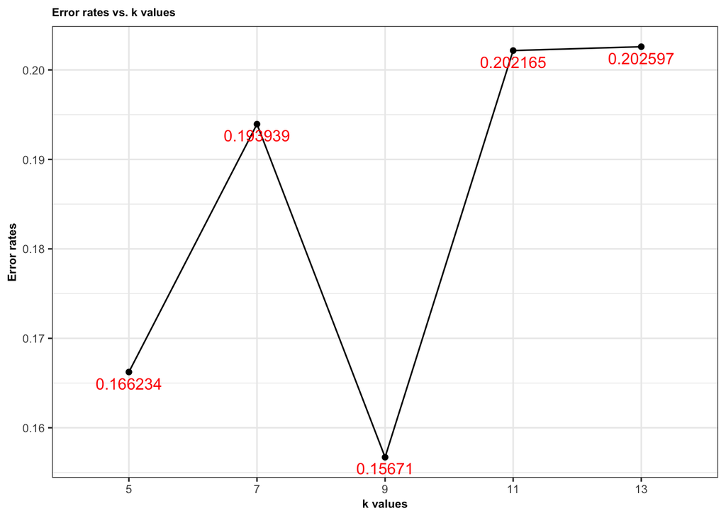

```r
# mean result
kfold=as.data.frame(cbind(mean_error_k,k=c(5,7,9,11,13)))
p5=ggplot(data = kfold,mapping =aes(x=as.factor(k),y=mean_error_k,group=1))+geom_line()+geom_point()+ggtitle ("Error rates vs. k values")+ylab("Error rates")+xlab("k values")+ geom_text(aes(label = round(mean_error_k,6)),vjust=1.5,color="red") + theme_bw()+theme(axis.text=element_text(size=8),axis.title=element_text(size=8,face="bold"),title = element_text(size = 6.5,face = "bold"))
p5
```

```r
# min k as required
min_k=kfold[which(kfold[,1]==min(kfold[,1])),2]
min_k
```

```
## [1] 9
```